# Bellabeat Data Analysis Case Study

### Introduction

Bellabeat, founded by Urška Sršen and Sando Mur, is a high-tech company that produces health-focused smart products for women. The aim of this case study is to analyze smart device data to uncover insights into consumer habits, which will inform Bellabeat’s marketing strategy and potentially unlock new growth opportunities.

# Ask

### Problem Statement

The primary objective is to analyze consumer usage data of non-Bellabeat smart devices, focusing on identifying trends and applying these insights to one of Bellabeat’s products. The analysis will guide the marketing strategy by answering the following questions:

- What are the trends in smart device usage?
- How could these trends apply to Bellabeat customers?
- How could these trends help influence Bellabeat marketing strategy?

### Stakeholders

Primary stakeholders:

- Urška Sršen: Bellabeat’s cofounder and Chief Creative Officer
- Sando Mur: Mathematician and Bellabeat’s cofounder

Secondary Stakeholders:

- Bellabeat marketing analytics team

# Prepare

#### Acknowledgement and Licensing

The dataset, created by Furberg, Robert; Brinton, Julia; Keating, Michael; and Ortiz, Alexa, is documented on [Zenodo](https://zenodo.org/record/53894#.YMoUpnVKiP9) and licensed under CC0: Public Domain.

#### Data Organization and Integrity

Organized in 18 CSV files, each focusing on different aspects of user activity, the dataset has been scrutinized for errors and inconsistencies to ensure its integrity and reliability.

# Process

### Tools and Data Cleaning

R is chosen as the primary tool for its extensive libraries and capabilities in handling, analyzing, and visualizing data. The data cleaning process involves formatting timestamps, merging data frames, and handling missing or erroneous data to ensure integrity.

### R Code for Data Loading

```r
# Load necessary libraries
library(tidyverse)
library(lubridate)

# Define the common path prefix
path_prefix <- "C:/Users/jorda/OneDrive/Documents/Coursera/Capstone/Fitabase Data 4.12.16-5.12.16/"

# Check if files exist before loading
files <- c("dailyActivity_merged.csv", "hourlyCalories_merged.csv",
           "hourlyIntensities_merged.csv", "sleepDay_merged.csv",
           "weightLogInfo_merged.csv")
for (file in files) {
  if (!file.exists(paste0(path_prefix, file))) {
    stop(paste0("File not found: ", path_prefix, file))
  }
}

# Load the data
activity <- read.csv(paste0(path_prefix, "dailyActivity_merged.csv"))
calories <- read.csv(paste0(path_prefix, "hourlyCalories_merged.csv"))
intensities <- read.csv(paste0(path_prefix, "hourlyIntensities_merged.csv"))
sleep <- read.csv(paste0(path_prefix, "sleepDay_merged.csv"))
weight <- read.csv(paste0(path_prefix, "weightLogInfo_merged.csv"))
```

### Data Cleaning and Formatting

```r
# Format timestamp columns
format_timestamp <- function(data, timestamp_col) {
  data[[timestamp_col]] <- as.POSIXct(data[[timestamp_col]], format="%m/%d/%Y %I:%M:%S %p", tz="UTC")
  data$date <- format(data[[timestamp_col]], format="%Y-%m-%d")
  data$time <- format(data[[timestamp_col]], format="%H:%M:%S")
  return(data)
}

# Apply the formatting function to relevant columns
intensities <- format_timestamp(intensities, "ActivityHour")
calories <- format_timestamp(calories, "ActivityHour")
activity$date <- as.Date(activity$ActivityDate, format="%m/%d/%Y")
sleep <- format_timestamp(sleep, "SleepDay")

# Merge the data frames using 'Id' and 'date' columns
merged_data <- merge(activity, sleep, by=c('Id', 'date'))
```

# Analyze

### Exploratory Data Analysis (EDA)

The analysis involves calculating summary statistics, performing correlation tests, and exploring relationships between different variables to identify patterns and trends in smart device usage.

```r
# Calculate summary statistics for various variables
variables <- c("TotalSteps", "Calories", "TotalMinutesAsleep", "TotalTimeInBed")
for (var in variables) {
  print(paste0("Summary Statistics for ", var, ":"))
  print(summary(merged_data[[var]]))
}
```

```
## [1] "Summary Statistics for TotalSteps:"
##    Min. 1st Qu.  Median    Mean 3rd Qu.    Max.
##      17    5206    8925    8541   11393   22770
## [1] "Summary Statistics for Calories:"
##    Min. 1st Qu.  Median    Mean 3rd Qu.    Max.
##     257    1850    2220    2398    2926    4900
## [1] "Summary Statistics for TotalMinutesAsleep:"
##    Min. 1st Qu.  Median    Mean 3rd Qu.    Max.
##    58.0   361.0   433.0   419.5   490.0   796.0
## [1] "Summary Statistics for TotalTimeInBed:"
##    Min. 1st Qu.  Median    Mean 3rd Qu.    Max.
##    61.0   403.0   463.0   458.6   526.0   961.0
```

```r
# Perform a correlation test between Total Steps and Calories Burned
cor_test <- cor.test(activity$TotalSteps, activity$Calories)
print("Correlation Test between Total Steps and Calories Burned:")
```

```
## [1] "Correlation Test between Total Steps and Calories Burned:"
```

```r
print(cor_test)
```

```
##
##  Pearson's product-moment correlation
##
## data:  activity$TotalSteps and activity$Calories
## t = 22.472, df = 938, p-value < 2.2e-16
## alternative hypothesis: true correlation is not equal to 0
## 95 percent confidence interval:
##  0.5483688 0.6316184
## sample estimates:
##       cor
## 0.5915681
```

### Interpretation of Results

- There is a significant positive correlation between Total Steps and Calories Burned (correlation coefficient: 0.59, p-value < 2.2e-16). This implies that as the number of steps increases, the number of calories burned also increases.
- Summary statistics for variables like TotalSteps, Calories, and TotalMinutesAsleep show varying ranges, indicating diversity in user behavior.

# Share

### Visualization

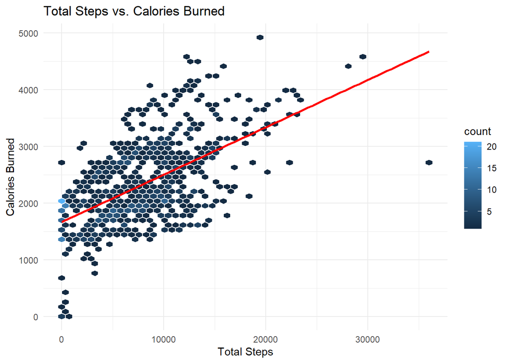

```r
# Total Steps vs. Calories Burned with Hexbin Plot and Regression Line
ggplot(data=activity, aes(x=TotalSteps, y=Calories)) +
  geom_hex(bins=50, color="white") +
  geom_smooth(method="lm", se=FALSE, color="red") +
  labs(title="Total Steps vs. Calories Burned", x="Total Steps", y="Calories Burned") +
  theme_minimal()
```

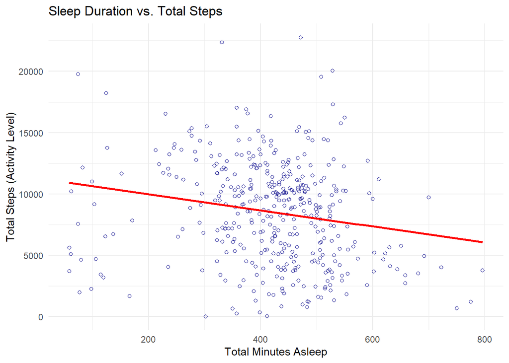

```r
# Sleep Duration vs. Total Steps (Activity Level) with Jitter and Regression Line
ggplot(data=merged_data, aes(x=TotalMinutesAsleep, y=TotalSteps)) +
  geom_jitter(shape=1, color="darkblue", width=0.3, height=0.3) +
  geom_smooth(method="lm", se=FALSE, color="red") +
  labs(title="Sleep Duration vs. Total Steps", x="Total Minutes Asleep", y="Total Steps (Activity Level)") +
  theme_minimal()
```

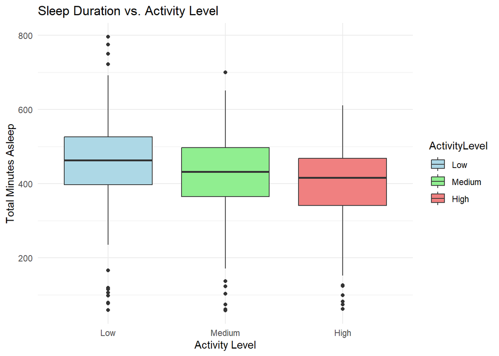

```r
# Define Activity Level based on Total Steps
merged_data$ActivityLevel <- cut(merged_data$TotalSteps,
                                 breaks = c(-Inf, 5000, 10000, Inf),
                                 labels = c("Low", "Medium", "High"))

# Sleep Duration vs. Activity Level with Box Plot
ggplot(data=merged_data, aes(x=ActivityLevel, y=TotalMinutesAsleep, fill=ActivityLevel)) +
  geom_boxplot() +
  labs(title="Sleep Duration vs. Activity Level", x="Activity Level", y="Total Minutes Asleep") +
  theme_minimal() +
  scale_fill_manual(values=c("Low" = "lightblue", "Medium" = "lightgreen", "High" = "lightcoral"))
```

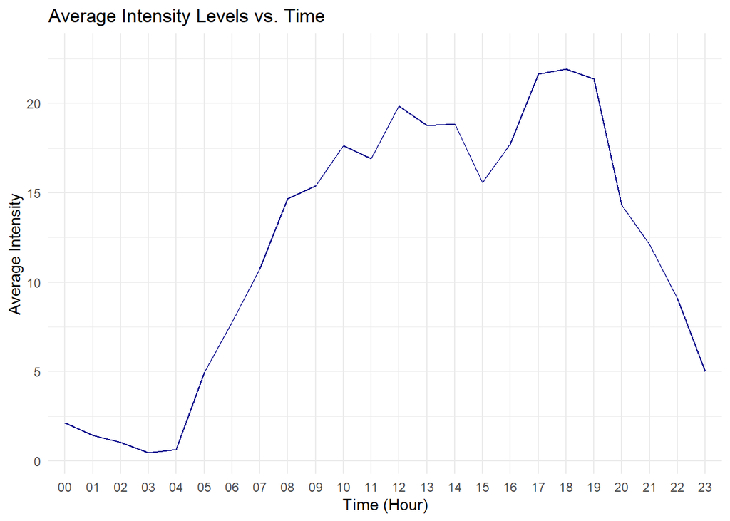

```r
# Average Intensity Levels vs. Time with Line Plot and Shading
intensity_avg <- intensities %>%
  group_by(time) %>%
  summarise(avg_intensity = mean(TotalIntensity), se = sd(TotalIntensity) / sqrt(n()))

# Convert 'time' to factor while keeping only the hour part for plotting
intensity_avg$time <- factor(format(strptime(intensity_avg$time, format="%H:%M:%S"), "%H"), levels = sprintf("%02d", 0:23))

# Create the line plot
ggplot(data=intensity_avg, aes(x=time, y=avg_intensity)) +
  geom_line(group=1, color='darkblue') +
  geom_ribbon(aes(ymin=avg_intensity-se, ymax=avg_intensity+se), alpha=0.2) +
  scale_x_discrete(breaks=sprintf("%02d", 0:23)) +
  theme(axis.text.x = element_text(angle=45, vjust=0.5, hjust=1)) +
  labs(title="Average Intensity Levels vs. Time", x="Time (Hour)", y="Average Intensity") +
  theme_minimal()
```

# Act

### Conclusions and Recommendations

- **Targeted Marketing Campaigns**: Develop marketing campaigns targeting users with varying activity levels and sleep patterns, emphasizing how Bellabeat products can help achieve a balance between activity and rest.
- **Personalized Health Goals**: Introduce features in Bellabeat app to set personalized daily step goals and sleep targets, encouraging users to maintain an active lifestyle while ensuring adequate rest.
- **Sleep and Activity Insights**: Enhance the Bellabeat app with insights on the correlation between sleep duration and physical activity, educating users on the importance of balancing both for overall well-being.
- **Peak Activity Notifications**: Send notifications during peak activity times to encourage workouts.
- **Wellness Challenges and Rewards**: Launch wellness challenges focusing on achieving step goals and maintaining healthy sleep patterns, with rewards to keep users engaged and motivated.
- **Educational Content**: Provide educational content and tips within the app on the benefits of regular physical activity and good sleep hygiene, helping users make informed lifestyle choices.
- **User Segmentation for Communication**: Utilize data on user behavior to segment users based on their activity levels and sleep durations for targeted communication and personalized recommendations.

A larger sample size is needed for a more accurate analysis. These recommendations aim to leverage the insights gained from the data analysis to enhance user engagement, promote healthy lifestyles, and drive growth for Bellabeat.